# Estimación de $\pi$

### Estimación de probabilidades

Sean $\mathbf{X}$ un vector aleatorio que sigue una distribución de probabilidad con función de densidad $f$ y $A \subseteq \mathbb{R}^{d}$ un conjunto de Borel y consideremos el problema de estimar $p = \mathbb{P}(\mathbf{X} \in A)$. Si definimos la *función indicador* $𝟙_{A}$ como
$$\begin{equation*}
𝟙_{A}(\mathbf{x}) =
\begin{cases}
1 & \text{si } \mathbf{x} \in A, \\
0 & \text{si } \mathbf{x} \not\in A.
\end{cases}
\end{equation*}$$
entonces se tiene
$$\begin{equation*}
\mathbb{P}(\mathbf{X} \in A) =
\int_{A} f(\mathbf{x}) \mathop{}\!\mathrm{d} \mathbf{x} =
\int_{\mathbb{R}^{d}} 𝟙_{A}(\mathbf{x}) f(\mathbf{x})
\mathop{}\!\mathrm{d} \mathbf{x} =
\mathbb{E}[𝟙_{A}(\mathbf{X})]
\end{equation*}$$
y podemos aplicar el método de Montecarlo para obtener la estimación.

Por tanto, basta generar $n$ valores independientes $\mathbf{x}_{1}, \dotsc, \mathbf{x}_{n} \sim f$ y calcular
$$\begin{equation*}
\hat{p}_{n} =
\frac{1}{n} \sum_{i = 1}^{n} 𝟙_{A}(\mathbf{x}_{i}) =
\frac{n_{A}}{n}
\end{equation*}$$
donde $n_{A}$ es la cantidad de valores generados que pertenecen al conjunto $A$.

Para construir un intervalo de confianza a partir del teorema central del límite necesitamos calcular el error estándar de $\hat{p}_{n}$:
$$\begin{equation*}
\mathrm{Var}(\hat{p}_{n}) =
\frac{1}{n^{2}} \sum_{i = 1}^{n}
\mathrm{Var}\bigl(𝟙_{A}(\mathbf{X})\bigr) =
\frac{\mathrm{Var}\bigl(𝟙_{A}(\mathbf{X})\bigr)}{n} =
\frac{\mathbb{E}\bigl[𝟙_{A}(\mathbf{X})^{2}\bigr] -
\mathbb{E}\bigl[𝟙_{A}(\mathbf{X})\bigr]^{2}}{n} =
\frac{p - p^{2}}{n} =
\frac{p (1 - p)}{n}
\end{equation*}$$
ya que $𝟙_{A}(\mathbf{X})^{2} = 𝟙_{A}(\mathbf{X})$.

Por tanto, un intervalo de confianza con probabilidad de cobertura $1 - \alpha$ sería
$$\begin{equation*}
\Bigl[
\hat{p}_{n} -
\sqrt{\frac{\hat{p}_{n} (1 - \hat{p}_{n})}{n}} z_{1 -
\frac{\alpha}{2}},
\hat{p}_{n} +
\sqrt{\frac{\hat{p}_{n} (1 - \hat{p}_{n})}{n}} z_{1 -
\frac{\alpha}{2}},
\Bigr]
\end{equation*}$$

Esta manera de obtener un intervalo de confianza se conoce como el método de Wald y proporciona usualmente intervalos con una probabilidad de cobertura menor a la requerida.

Una manera de obtener mejores intervalos de confianza, en el sentido de que la probabilidad de cobertura es más cercana a la requerida, es el método de Agresti-Coull. Este consiste en añadir unas pseudocuentas $n_{0}$ y $n_{1}$ de valores fuera y dentro, respectivamente, del conjunto $A$. Estas pseudocuentas únicamente dependen del nivel de confianza requerido, en concreto $n_{0} = n_{1} = z_{1 - \frac{\alpha}{2}}^{2}/2$. De esta forma,
$$\begin{align*}
\tilde{n} &= n + n_{0} + n_{1} \\
\tilde{p}_{n} &= \frac{n_{A} + n_{1}}{\tilde{n}}
\end{align*}$$
y un intervalo de confianza con probabilidad de cobertura $1 - \alpha$ sería
$$\begin{equation*}
\Bigl[
\tilde{p}_{n} -
\sqrt{\frac{\tilde{p}_{n} (1 - \tilde{p}_{n})}{\tilde{n}}}
z_{1 - \frac{\alpha}{2}},
\tilde{p}_{n} +
\sqrt{\frac{\tilde{p}_{n} (1 - \tilde{p}_{n})}{\tilde{n}}}
z_{1 - \frac{\alpha}{2}},
\Bigr]
\end{equation*}$$

Fijado el valor $n_{A}$ y usando que entonces la función de distribución de la binomial considerada como función de la probabilidad de éxito $p$ es continua y decreciente, una forma de obtener un intervalo de confianza conservativo que asegure al menos el nivel de confianza $1 - \alpha$ requerido es considerar el intervalo $(p_{I}, p_{D})$ tal que
$$\begin{equation*}
\mathbb{P}_{\mathrm{binom}(n, p_{I})} \Bigl(\sum_{i = 1}^{n}
𝟙_{A}(\mathbf{x}_{i}) \geq n_{A}\Bigr) =
\frac{\alpha}{2}
\quad\text{y}\quad
\mathbb{P}_{\mathrm{binom}(n, p_{D})} \Bigl(\sum_{i = 1}^{n}
𝟙_{A}(\mathbf{x}_{i}) \leq n_{A}\Bigr) =
\frac{\alpha}{2}
\end{equation*}$$

Teniendo en cuenta la relación entre la distribución binomial y la distribución beta, se tiene que
$$\begin{equation*}
p_{I} = F_{\mathrm{beta}(n_{A}, n - n_{A} + 1)}^{-1}
\Bigl(\frac{\alpha}{2}\Bigr)
\quad\text{y}\quad
p_{D} = F_{\mathrm{beta}(n_{A} + 1, n - n_{A})}^{-1} \Bigl(1 -
\frac{\alpha}{2}\Bigr)
\end{equation*}$$

### Aplicación a la estimación de $\pi$

Vamos a aplicar lo anterior para realizar una estimación del valor del número $\pi$. Para ello, consideremos el vector aleatorio $\mathbf{U} = (X, Y) \sim \mathrm{U}\bigl((0, 1)^{2}\bigr)$ y el conjunto
$$\begin{equation*}
A = \{(x, y) \in (0, 1)^{2} \mid x^{2} + y^{2} \leq 1\}
\end{equation*}$$
que se puede visualizar en el siguiente gráfico:

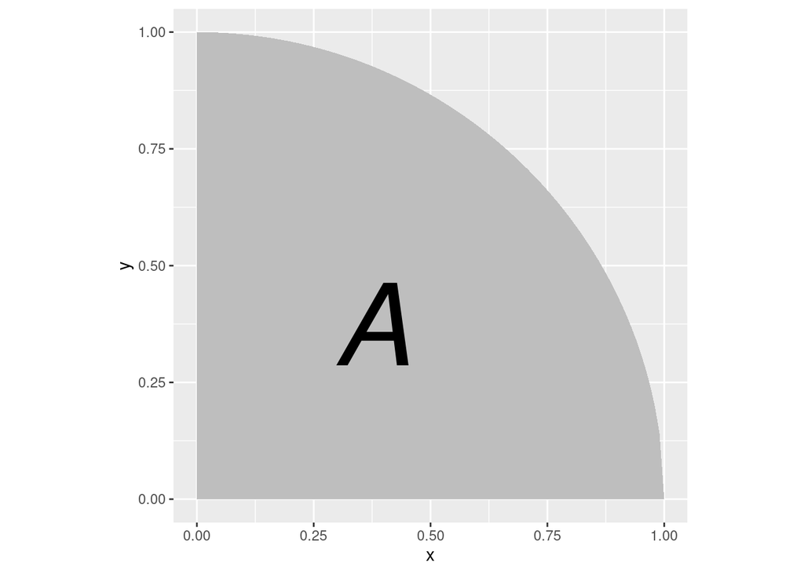

Entonces,
$$\begin{equation*}
\mathbb{P}\bigl((X, Y) \in A\bigr) =
\int_{A} 1 \mathop{}\!\mathrm{d} x \mathop{}\!\mathrm{d} y =
\frac{\pi}{4}
\end{equation*}$$
y podemos estimar su valor mediante el método de Montecarlo.

Empezamos estableciendo la forma de generar valores del vector aleatorio y definiendo la función $g$ que se aplicará a esos valores, que en este caso se trata de la función indicador del conjunto $A$.

```r
genera_vector_aleatorio <- function() {
  runif(2)
}

g <- function(u) {
  x <- u[1]
  y <- u[2]
  x^2 + y^2 <= 1
}
```

Nótese que, tal y como la hemos definido, la función indicador devuelve `TRUE` o `FALSE`. No obstante, al realizar posteriormente operaciones aritméticas R transformará esos valores a `1` y `0`, respectivamente, por lo que no habrá ningún problema.

Ahora basta replicar la generación de valores aleatorios uniformes en el cuadrado $(0, 1) \times (0, 1)$ y determinar si pertenecen o no al conjunto $A$.

```r
n <- 1e3
valores <- replicate(n, {
  u <- genera_vector_aleatorio()
  g(u)
})
```

Finalmente, estimamos el valor de $\pi / 4$ a partir de los valores generados y construimos intervalos de confianza según el método general de Montecarlo y según los tres métodos explicados, todos con la misma probabilidad de cobertura para que tenga sentido compararlos.

```r
# La mejor manera de contar en R cuántos objetos verifican una propiedad
# es determinar para cada uno de ellos si cumple o no la propiedad y
# sumar los resultados.
n_A <- sum(valores)

probabilidad_cobertura <- 0.95
alfa <- 1 - probabilidad_cobertura
percentil <- qnorm(1 - alfa / 2)

# Calculamos un intervalo de confianza según el método de Montecarlo
estimacion_Montecarlo <- n_A / n
error_estandar_Montecarlo <- sqrt(var(valores) / n)
intervalo_Montecarlo <-
  estimacion_Montecarlo + c(-1, 1) * error_estandar_Montecarlo * percentil

# Calculamos un intervalo de confianza según el método de Wald
estimacion_Wald <- n_A / n
error_estandar_Wald <- sqrt(estimacion_Wald * (1 - estimacion_Wald) / n)
intervalo_Wald <-
  estimacion_Wald + c(-1, 1) * error_estandar_Wald * percentil

# Calculamos un intervalo de confianza según el método de Agresti-Coull
n_0 <- n_1 <- percentil^2 / 2
n_Agresti_Coull <- (n + n_0 + n_1)
estimacion_Agresti_Coull <- (n_A + n_1) / n_Agresti_Coull
error_estandar_Agresti_Coull <-
  sqrt(estimacion_Agresti_Coull * (1 - estimacion_Agresti_Coull) /
    n_Agresti_Coull)
intervalo_Agresti_Coull <-
  estimacion_Agresti_Coull + c(-1, 1) * error_estandar_Agresti_Coull * percentil

# Calculamos un intervalo de confianza según el método conservativo
p_I <- qbeta(alfa / 2, shape1 = n_A, shape2 = n - n_A + 1)
p_D <- qbeta(1 - alfa / 2, shape1 = n_A + 1, shape2 = n - n_A)
estimacion_conservativo <- n_A / n
intervalo_conservativo <- c(p_I, p_D)
```

Teniendo en cuenta que el valor que se ha estimado es $\pi / 4$, para obtener una estimación de $\pi$ hay que multiplicar por $4$ tanto las estimaciones como los intervalos de confianza obtenidos. Se tiene entonces lo siguiente:

```r
estimaciones <- 4 * c(
  estimacion_Montecarlo,
  estimacion_Wald,
  estimacion_Agresti_Coull,
  estimacion_conservativo
)
errores <- 4 * c(
  error_estandar_Montecarlo,
  error_estandar_Wald,
  error_estandar_Agresti_Coull,
  NA
)
intervalos <- 4 * rbind(
  intervalo_Montecarlo,
  intervalo_Wald,
  intervalo_Agresti_Coull,
  intervalo_conservativo
)
knitr::kable(
  data.frame(
    Intervalo = c("Montecarlo", "Wald", "Agresti-Coull", "Conservativo"),
    Estimación = estimaciones,
    `Error estándar` = errores,
    Intervalo = intervalos,
    Longitud = apply(intervalos, 1, diff)
  ),
  row.names = FALSE,
  digits = 10
)
```

| Intervalo | Estimación | Error.estándar | Intervalo.1 | Intervalo.2 | Longitud |
| --- | --- | --- | --- | --- | --- |
| Montecarlo | 3.204000 | 0.05052660 | 3.104970 | 3.303030 | 0.1980606 |
| Wald | 3.204000 | 0.05050133 | 3.105019 | 3.302981 | 0.1979616 |
| Agresti-Coull | 3.199393 | 0.05051391 | 3.100387 | 3.298398 | 0.1980109 |
| Conservativo | 3.204000 | NA | 3.099536 | 3.301320 | 0.2017834 |